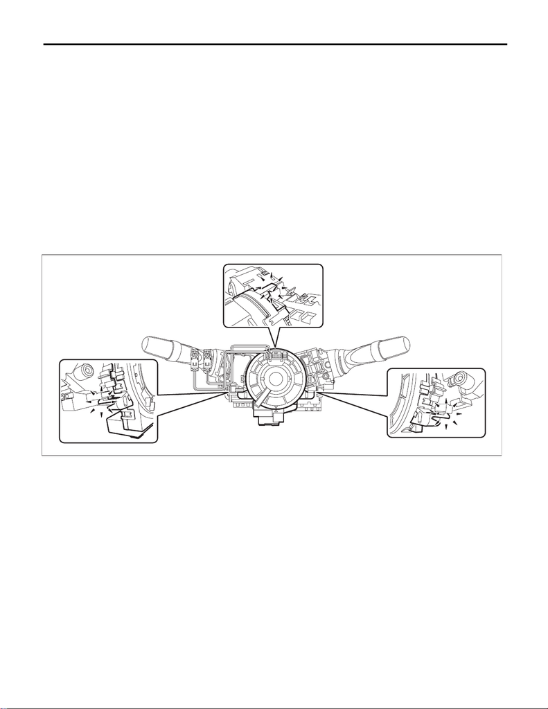

AB-60

Roll Connector

AIRBAG SYSTEM

15.Roll Connector

A: REMOVAL

1) Position the front wheels straight ahead.

2) Turn the ignition switch to OFF.

3) Disconnect the ground cable from battery and wait for at least 60 seconds before starting work. <Ref. to

NT-5, BATTERY, NOTE, Note.>

NOTE:

For models other than STI model, disconnect the ground terminal from battery sensor.

4) Remove the driver’s airbag module. <Ref. to AB-33, REMOVAL, Driver’s Airbag Module.>

5) Remove the steering wheel. <Ref. to PS-16, REMOVAL, Steering Wheel.>

6) Remove the cover assembly - column. <Ref. to PS-25, REMOVAL, Steering Column.>

7) Remove the roll connector.

CAUTION:

Make sure that the roll connector is not turned from the original position.

(1) Disconnect the connector under the roll connector.

(2) Release the claws and remove the roll connector.

AB-02914

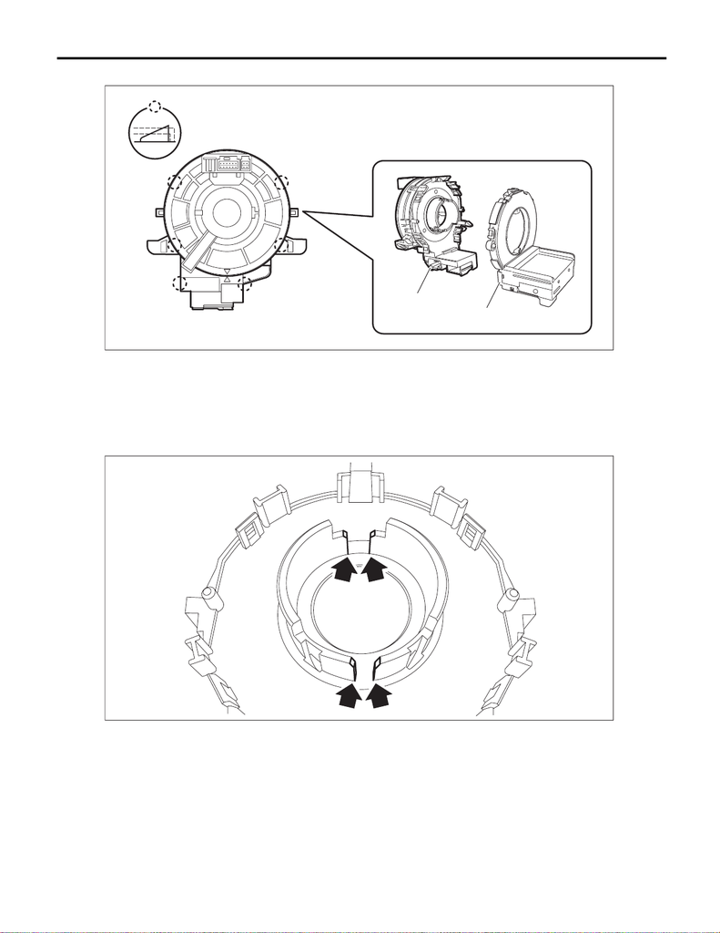

AB-61

Roll Connector

AIRBAG SYSTEM

(3) Release the claws and separate the roll connector (a) and steering angle sensor (b).

B: INSTALLATION

CAUTION:

If the steering wheel and steering angle sensor are removed, perform “VDC sensor midpoint setting

mode” of the VDC.

1) Before attaching a new roll connector, apply a thin coat of grease contained in the connector onto the ar-

eas shown by the arrows.

2) Install the cover assembly - column.

3) Install the roll connector.

4) Align the center position of the steering roll connector. <Ref. to AB-64, ADJUSTMENT, Roll Connector.>

5) Install the steering wheel.

Tightening torque:

Steering wheel: 39 N·m (4.0 kgf-m, 28.8 ft-lb)

Clearance:

Between cover assembly - column and steering wheel: 4 — 6 mm (0.16 — 0.24 in)

6) Install the driver’s airbag module. <Ref. to AB-34, INSTALLATION, Driver’s Airbag Module.>

AB-02945

(a)

(b)

AB-02722

[figure not shown]

AB-62

Roll Connector

AIRBAG SYSTEM

7) Connect the battery ground terminal. <Ref. to NT-5, BATTERY, NOTE, Note.>

NOTE:

For models other than STI model, connect the ground terminal to battery sensor.

8) Perform the neutral position setting of the steering angle sensor. <Ref. to VDC-16, VDC SENSOR MID-

POINT SETTING MODE, ADJUSTMENT, VDC Control Module and Hydraulic Control Unit (VDCCM&H/U).>

C: INSPECTION

1. VISUAL INSPECTION

Check for the following, and replace the damaged parts with new parts.

• Combination switch is cracked or deformed.

• Roll connector is cracked or deformed.

2. UNIT INSPECTION OF ROLL CONNECTOR

CAUTION:

• Do not rotate the roll connector to more than the specified number of turns. Otherwise, the roll con-

nector internal wire may be broken.

• When determining the end stop, rotate the connector slowly without applying excessive force. Ap-

plying excessive force at the end stop may break the internal wire.

1) Adjust the roll connector. <Ref. to AB-64, ADJUSTMENT, Roll Connector.>

2) Set the roll connector to the central position.

3) Connect the test harness to the connector E and connector F.

Preparation tool:

Test harness N (98299SA000)

Test harness Q (98299SA040)

• Connector E - Test harness N (1N)

• Connector F - Test harness Q (1Q)

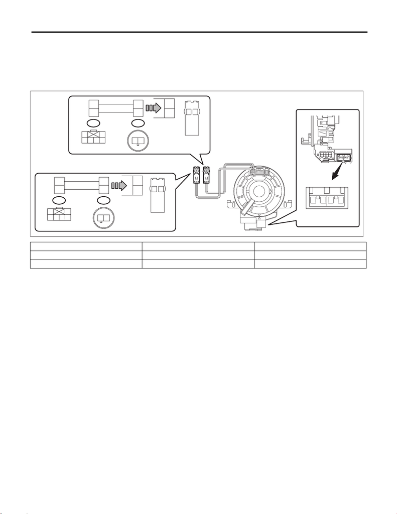

AB-63

Roll Connector

AIRBAG SYSTEM

4) With the following conditions, check the resistance between the test harness connector terminals.

• Perform the check with the roll connector centered (front wheels direct straightforward).

Preparation tool:

Circuit tester

NOTE:

The connector D is designed to short the terminals D1/D2 and D3/D4 when disconnected.

5) Replace the roll connector with a new part if the inspection result is not within the standard.

Terminal No. Inspection conditions Standard

(2Q) No. 1 — (2Q) No. 2 Always Less than 1 Ω

AB-02915

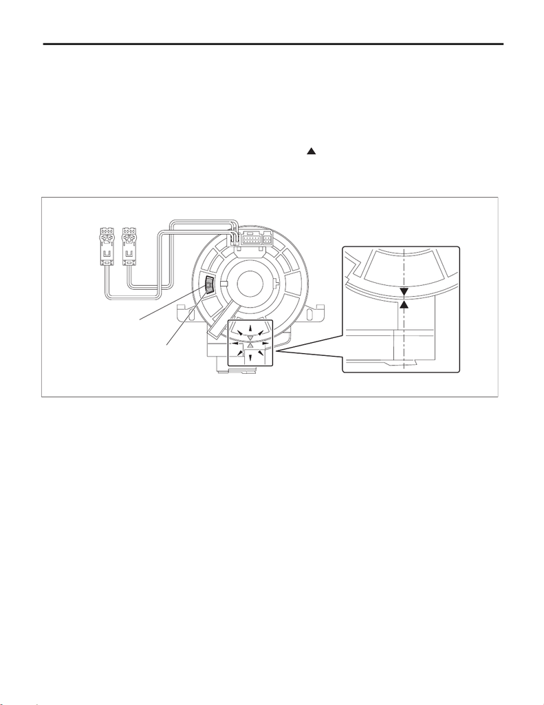

AB-64

Roll Connector

AIRBAG SYSTEM

D: ADJUSTMENT

CAUTION:

• Do not rotate the roll connector to more than the specified number of turns. Otherwise, the roll con-

nector internal wire may be broken.

• When determining the end stop, rotate the connector slowly without applying excessive force. Ap-

plying excessive force at the end stop may break the internal wire.

1) Check that front wheels are positioned in straight ahead direction.

2) Rotate the roll connector counterclockwise until it stops.

NOTE:

When the roll connector comes to the center position, the orange roller (b) can be seen from the sight glass

(a).

AB-02916

(a)

(b)